# A5 - On-time performance: Model and Join

Aditya, Apoorv, Dhvani

October 19, 2017

### Problem Statement:

Given historical airplane on time performance data, offer suggestions for two-hop flights that minimize the chance of missing a connection.

### Implementation - Flow Diagram

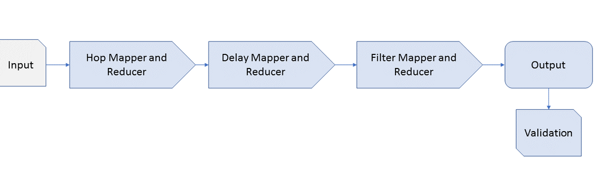

### Implementation

The implementation is divided into following parts:

1. The first map reduce job fetches all the possible combinations of two hop flights based on the input provided.
- The mapper fetches all the flights which have the origin equal to origin in the input but destination not equal to that in input (to filter out direct flights). Similarly, it fetches all the flights which have destination equal to destination in the input but origin not equal to origin in input (to filter out direct flights). This way mapper outputs all the two hop flights possible between the origin and destination mentioned in the input.
- Thus, the output of the mapper is one of either Key - Airport, Value -{‘Firsthop’, Flightdetails} or Key - Airport, Value - {‘Secondhop’, Flightdetails}
- The reducer then combines all the two hop flights possible between the given origin and destination in input and emits out Key - {Year, Month, Day, Origin, Destination}, Value - {Firsthop Flight details, Secondhop Flight details} Note: In this step we calculate these output pairs based on the Scheduled Arrival and Scheduled Departure times.
2. Next, we run another map reduce phase to compute the mean delay (based on arrival time) for each airline by origin and destination over all the years prior to the year in the input and simultaneously the fraction of flights that were cancelled (total flights cancelled/total flights)
- The output of this map reduce phase is Key - {Month, Airline, Destination, Origin}, Value - {Mean Arrival Delay, Fraction of flights cancelled}
3. This phase involves filtering out the flight hop pairs of record based on the mean delay and cancellation data we got in previous step. We are mainly interested in; if after adding the mean delay observed over the years to the arrival time causes the second flight to be missed or if the flight is historically cancelled more than 20% of the time. (This 20% needs to be fine tuned).
- We have two mappers reading from two different files emitting a common key Mapper 1: Key - {Month, Airline, Origin, Destination}, Value - {“Firsthop”, Full line as read from the hop reducer’s output} Mapper 2: Key - {Month, Airline, Origin, Destination}, Value - {“DelayAndCancellation”, MeanDelay, CancellationFraction}
4. We run the above filter phase again, but this time we look at only the second hop flights and look to eliminate the flight hop pair if the second flight is cancelled by more than 20% historically. We also compute the number of records which are correct and incorrect using global counters in map reduce. “Correct” here means those records which are present in our output where the connection was not missed. “Incorrect” means the output record contains a first flight which was cancelled or connection was missed or a second flight which was cancelled.
- Note: Steps 3 and 4 take only about 30 seconds each (for all our experiments).
5. The final phase is the validation phase where we compute the different flight connections for the inputs based on the actual time the flights arrive and depart at the hop destination on that day . And we compute the number of records we output as this gives a number which indicates the total number of correct connections. Note that we reuse the code from first step.

### Task Distribution

Design: Aditya, Apoorv, Dhvani  
HopMapper and Reducer: Aditya and Apoorv DelayCancelMapper and Reducer: Aditya and Dhvani  
FilterMapper: Aditya, Apoorv, Dhvani  
Report: Aditya, Apoorv, Dhvani

### Configuration of the machines used

The program was intially run on AWS EMR with one namenode and four datanodes on the whole dataset. Later, we increased the number of datanodes to 8.

Below is the configuration of the machines used (m4.xlarge):  
Namenode and Datanodes: vCPU: 4 RAM: 16GB Hard Disk: 70GB SSD Storage: EBS-only

Processors for all the above machines were 64 bit 2.4 GHz Intel Xeon® E5-2676 v3 (Haswell) processors. Each vCPU is a hyperthread of an Intel Xeon core.

### Performance

Following is the perfromance achieved by running the program on AWS EMR configurations mentioned above.

| Iteration | Name Nodes | Data Nodes | Runtime |
| --- | --- | --- | --- |
| 1 | 1 | 4 | 29 minutes |
| 2 | 1 | 8 | 16 minutes |
| 3 | 1 | 8 | 16 minutes |

### Results

#### Experiment 1

Input:

```
2001,7,4,JFK,LAX
2001,7,4,BOS,LAX
2001,12,5,DEN,ORD
```

Total number of flights with two hops not missing the connection was **3561**. We calculated this using actual arrival time, actual departure time and whether either of the flights in the hops were cancelled or not and layover conditions (>45 and <720 minutes) were met.

After the first step where we get the two hop flights connections by considering only the CRS scheduled time, following was the result :-

| Correct connections | Incorrect connections |
| --- | --- |
| 3410 | 193 |

*correct connections : the two hop connection, where layover conditions were met and neither flights were cancelled (Calculated using actual times)* *incorrect connections : the two hop connection, where layover conditions were not met and either flights were cancelled (Calculated using actual times)*

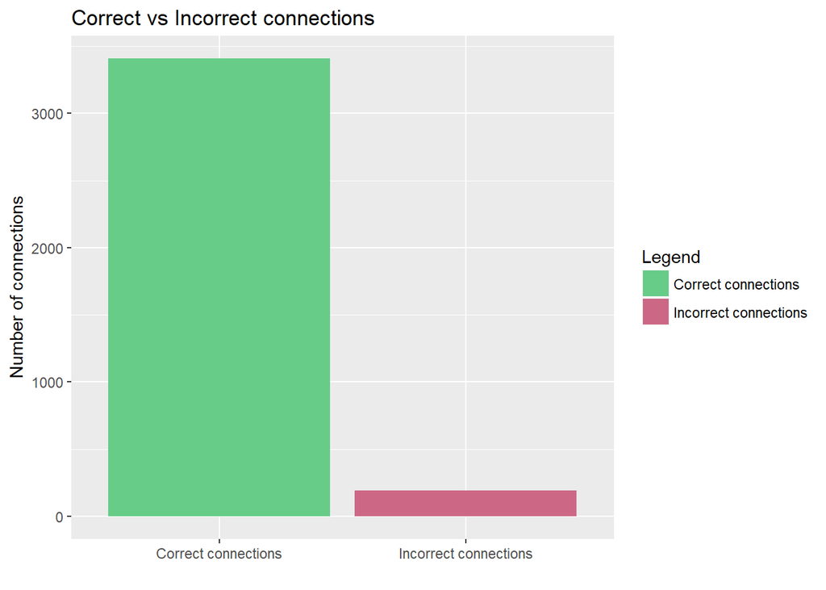

After predicting the two flight hops to be taken, following was the result

| Correct Predicted connections | Incorrect Predicted connections |
| --- | --- |
| 3263 | 134 |

*correct connections : the two hop connection, where layover conditions were met and neither flights were cancelled (Calculated using actual times)* *incorrect connections : the two hop connection, where layover conditions were not met and either flights were cancelled (Calculated using actual times)*

| Total correct connections |
| --- |
| 3561 |

*total correct connections : the total number of two hop connections which were on time*

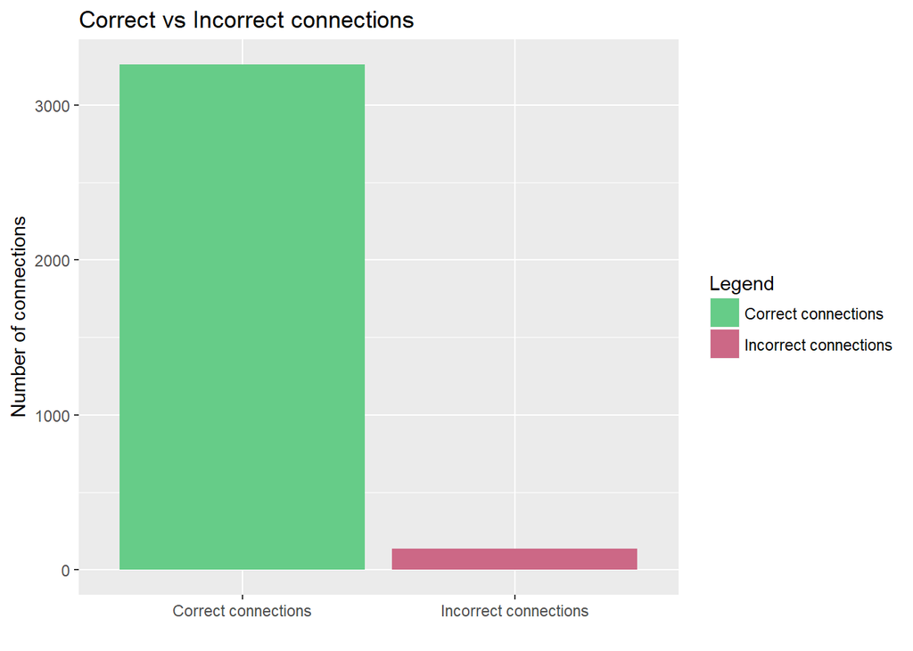

Precision and accuracy:

| Precision | Accuracy |
| --- | --- |
| 0.96 | 0.91 |

Precision is calculated as (Number of True Positives) / (Number of True Positives + Number of False Positives)

Accuracy is calculated as (Correct connections fetched) / (Total correct connections)

**Conclusion** Our final output consisted of 3397 two hop flight suggestions. Out of these records 3263 records were correct predictions and 134 were incorrect predictions. We validated our result by comparing it to the actual arrival time, departure time and cancellation time of the flights we have generated as output.  
The accuracy of using the average delay and cancellation probability as model is 91% with a precision of 96% for the above experiment.

#### Experiment 2

Input:

```
2014,7,4,JFK,LAX
2014,7,4,BOS,LAX
2014,12,5,DEN,ORD
2014,3,4,ATL,SLC
2014,6,7,TUS,SIT
```

Total number of flights with two hops not missing the connection was **3746**. We calculated this using actual arrival time, actual departure time and whether either of the flights in the hops were cancelled or not and layover conditions (>45 and <720 minutes) were met.

After the first step where we get the two hop flights connections by considering only the CRS scheduled time, following was the result :-

| Correct connections | Incorrect connections |
| --- | --- |
| 3463 | 194 |

*correct connections : the two hop connection, where layover conditions were met and neither flights were cancelled (Calculated using actual times)* *incorrect connections : the two hop connection, where layover conditions were not met and either flights were cancelled (Calculated using actual times)*

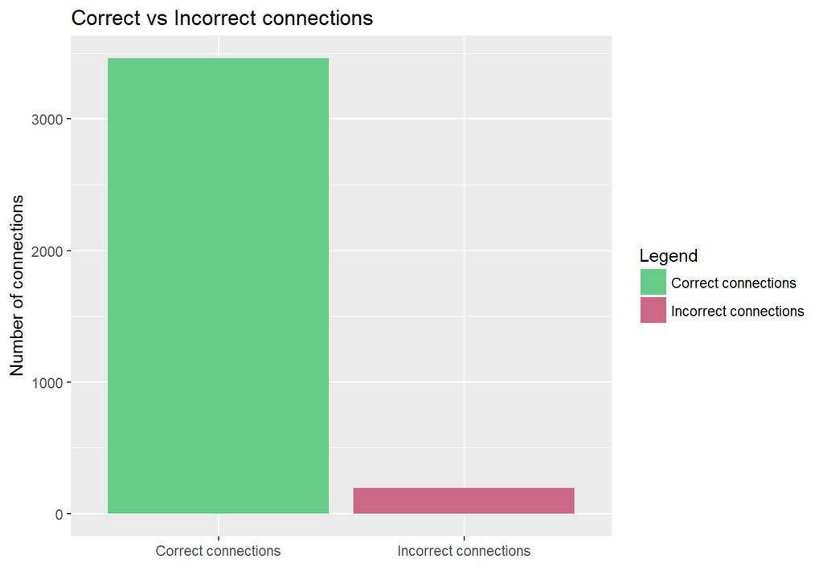

After predicting the two flight hops to be taken, following was the result

| Correct Predicted connections | Incorrect Predicted connections |
| --- | --- |
| 3314 | 141 |

*correct connections : the two hop connection, where layover conditions were met and neither flights were cancelled (Calculated using actual times)* *incorrect connections : the two hop connection, where layover conditions were not met and either flights were cancelled (Calculated using actual times)*

| Total correct Hops |
| --- |
| 3746 |

*total correct connections : the total number of two hop connections which were on time*

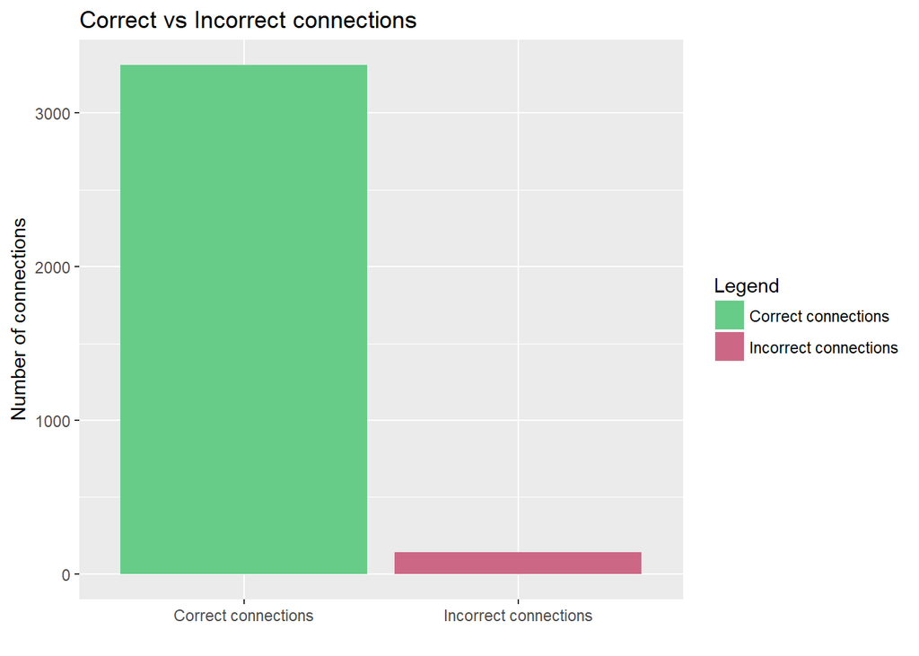

Precision and accuracy:

| Precision | Accuracy |
| --- | --- |
| 0.95 | 0.88 |

Precision is calculated as (Number of True Positives) / (Number of True Positives + Number of False Positives)

Accuracy is calculated as (Correct connections fetched) / (Total correct connections)

**Conclusion** Our final output consisted of 3455 two hop flight suggestions. Out of these records, 3314 records were correct predictions and 141 were incorrect predictions. We validated our result by comparing it to the actual arrival time, departure time and cancellation time of the flights we have generated as output.  
The accuracy of using the average delay and cancellation probability as model is 88% with a precision of 95% for the above experiment.

#### Experiment 3

Input:

```
2009,7,4,JFK,LAX
2009,7,4,BOS,LAX
2009,12,5,DEN,ORD
2009,3,4,ATL,SLC
2009,6,7,TUS,SIT
```

Total number of flights with two hops not missing the connection was **3618**. We calculated this using actual arrival time, actual departure time and whether either of the flights in the hops were cancelled or not and layover conditions (>45 and <720 minutes) were met.

After the first step where we get the two hop flights connections by considering only the CRS scheduled time, following was the result :-

| Correct connections | Incorrect connections |
| --- | --- |
| 3354 | 179 |

*correct connections : the two hop connection, where layover conditions were met and neither flights were cancelled (Calculated using actual times)* *incorrect connections : the two hop connection, where layover conditions were not met and either flights were cancelled (Calculated using actual times)*

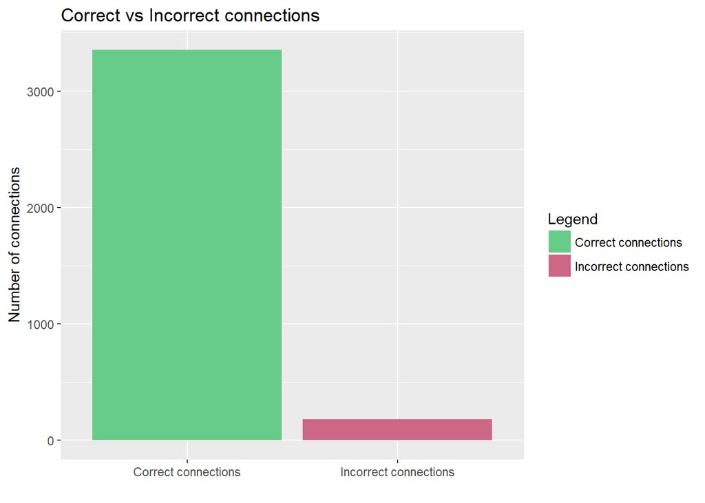

After predicting the two flight hops to be taken, following was the result

| Correct Predicted connections | Incorrect Predicted connections |
| --- | --- |
| 3228 | 97 |

*correct connections : the two hop connection, where layover conditions were met and neither flights were cancelled (Calculated using actual times)* *incorrect connections : the two hop connection, where layover conditions were not met and either flights were cancelled (Calculated using actual times)*

| Total correct Hops |
| --- |
| 3618 |

*total correct connections : the total number of two hop connections which were on time*

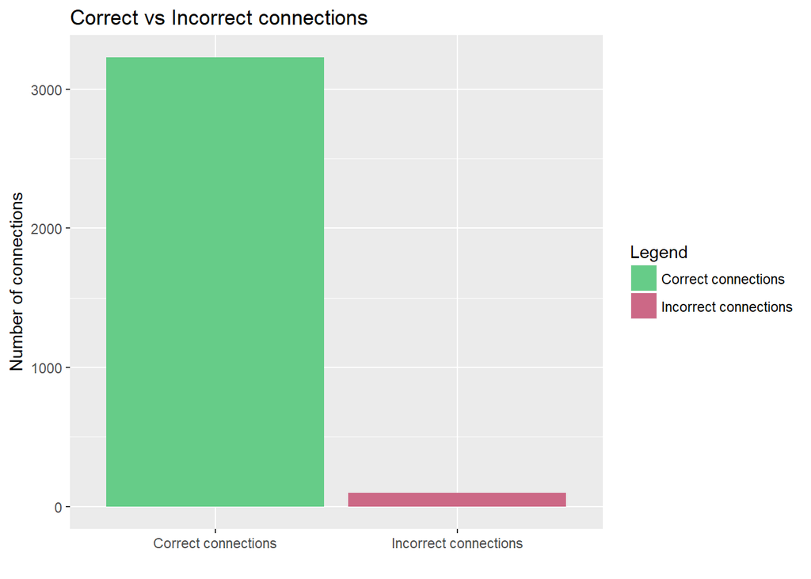

Precision and accuracy:

| Precision | Accuracy |
| --- | --- |
| 0.97 | 0.89 |

Precision is calculated as (Number of True Positives) / (Number of True Positives + Number of False Positives)

Accuracy is calculated as (Correct connections fetched) / (Total correct connections)

**Conclusion** Our final output consisted of 3325 two hop flight suggestions. Out of these records 3228 records were correct predictions and 97 were incorrect predictions. We validated our result by comparing it to the actual arrival time, departure time and cancellation time of the flights we have generated as output.  
The accuracy of using the average delay and cancellation probability as model is 89% with a precision of 97% for the above experiment.

The input query and the outputs for the experiment 1 and 3 are there in the folders input_output_1 and input_output_3 respectively.